# Unsupervised Learning: Trade&Ahead

### Context

The stock market has consistently proven to be a good place to invest in and save for the future. There are a lot of compelling reasons to invest in stocks. It can help in fighting inflation, create wealth, and also provides some tax benefits. Good steady returns on investments over a long period of time can also grow a lot more than seems possible. Also, thanks to the power of compound interest, the earlier one starts investing, the larger the corpus one can have for retirement. Overall, investing in stocks can help meet life's financial aspirations.

It is important to maintain a diversified portfolio when investing in stocks in order to maximise earnings under any market condition. Having a diversified portfolio tends to yield higher returns and face lower risk by tempering potential losses when the market is down. It is often easy to get lost in a sea of financial metrics to analyze while determining the worth of a stock, and doing the same for a multitude of stocks to identify the right picks for an individual can be a tedious task. By doing a cluster analysis, one can identify stocks that exhibit similar characteristics and ones which exhibit minimum correlation. This will help investors better analyze stocks across different market segments and help protect against risks that could make the portfolio vulnerable to losses.

### Objective

Trade&Ahead is a financial consultancy firm who provide their customers with personalized investment strategies. They have hired you as a Data Scientist and provided you with data comprising stock price and some financial indicators for a few companies listed under the New York Stock Exchange. They have assigned you the tasks of analyzing the data, grouping the stocks based on the attributes provided, and sharing insights about the characteristics of each group.

### Data Dictionary

- Ticker Symbol: An abbreviation used to uniquely identify publicly traded shares of a particular stock on a particular stock market
- Security: Name of the company
- GICS Sector: The specific economic sector assigned to a company by the Global Industry Classification Standard (GICS) that best defines its business operations
- GICS Sub Industry: The specific sub-industry group assigned to a company by the Global Industry Classification Standard (GICS) that best defines its business operations
- Current Price: Current stock price in dollars
- Price Change: Percentage change in the stock price in 13 weeks
- Volatility: Standard deviation of the stock price over the past 13 weeks
- ROE: A measure of financial performance calculated by dividing net income by shareholders' equity (shareholders' equity is equal to a company's assets minus its debt)
- Cash Ratio: The ratio of a company's total reserves of cash and cash equivalents to its total current liabilities
- Net Cash Flow: The difference between a company's cash inflows and outflows (in dollars)
- Net Income: Revenues minus expenses, interest, and taxes (in dollars)
- Earnings Per Share: Company's net profit divided by the number of common shares it has outstanding (in dollars)
- Estimated Shares Outstanding: Company's stock currently held by all its shareholders
- P/E Ratio: Ratio of the company's current stock price to the earnings per share
- P/B Ratio: Ratio of the company's stock price per share by its book value per share (book value of a company is the net difference between the company's total assets and total liabilities)

## Importing Libraries

```python
# Suppressing warnings
import warnings
warnings.filterwarnings('ignore')

# Measuring the passage of time
from time import time

# Data management libraries
import numpy as np
import pandas as pd

# Data visualization libraries
import matplotlib.pyplot as plt
import seaborn as sns
%matplotlib inline

# Data preprocessing libraries
from sklearn.preprocessing import StandardScaler, MinMaxScaler
from scipy.stats import zscore

# Clustering libraries
from sklearn.cluster import KMeans, AgglomerativeClustering
from scipy.spatial.distance import cdist, pdist
from sklearn.metrics import silhouette_score
from scipy.cluster.hierarchy import linkage, cophenet, dendrogram
from yellowbrick.cluster import KElbowVisualizer, SilhouetteVisualizer

# Setting the theme and fontsize of figures
sns.set_theme(style = 'darkgrid', font_scale = 1.13)
# Restricting the float value of a dataframe to 3 decimal points
pd.set_option('display.float_format', lambda x: '%.3f' % x)
# Removing the limit for the number of displayed columns in a dataframe
pd.set_option("display.max_columns", None)

# Mounting the drive
from google.colab import drive
drive.mount('/content/drive/')
```

## Importing the Dataset

```python
# Loading the dataset
data_orig = pd.read_csv('/content/drive/MyDrive/Python_files/stock_data.csv')
# Ensuring the original data remains unchanged
df = data_orig.copy()
```

## Data Overview

- Observations
- Sanity checks

### Shape of the Dataset

```python
print('The dataset consists of {} rows and {} columns.'.format(df.shape[0], df.shape[1]))
```

```
The dataset consists of 340 rows and 15 columns.
```

### Displaying Sample Rows of the Dataset

```python
# First five rows
df.head()
```

|  | Ticker Symbol | Security | GICS Sector | GICS Sub Industry | Current Price | Price Change | Volatility | ROE | Cash Ratio | Net Cash Flow | Net Income | Earnings Per Share | Estimated Shares Outstanding | P/E Ratio | P/B Ratio |
| --- | --- | --- | --- | --- | --- | --- | --- | --- | --- | --- | --- | --- | --- | --- | --- |
| 0 | AAL | American Airlines Group | Industrials | Airlines | 42.350 | 10.000 | 1.687 | 135 | 51 | -604000000 | 7610000000 | 11.390 | 668129938.500 | 3.718 | -8.784 |
| 1 | ABBV | AbbVie | Health Care | Pharmaceuticals | 59.240 | 8.339 | 2.198 | 130 | 77 | 51000000 | 5144000000 | 3.150 | 1633015873.000 | 18.806 | -8.750 |
| 2 | ABT | Abbott Laboratories | Health Care | Health Care Equipment | 44.910 | 11.301 | 1.274 | 21 | 67 | 938000000 | 4423000000 | 2.940 | 1504421769.000 | 15.276 | -0.394 |
| 3 | ADBE | Adobe Systems Inc | Information Technology | Application Software | 93.940 | 13.977 | 1.358 | 9 | 180 | -240840000 | 629551000 | 1.260 | 499643650.800 | 74.556 | 4.200 |
| 4 | ADI | Analog Devices, Inc. | Information Technology | Semiconductors | 55.320 | -1.828 | 1.701 | 14 | 272 | 315120000 | 696878000 | 0.310 | 2247993548.000 | 178.452 | 1.060 |

```python
# Last five rows
df.tail()
```

|  | Ticker Symbol | Security | GICS Sector | GICS Sub Industry | Current Price | Price Change | Volatility | ROE | Cash Ratio | Net Cash Flow | Net Income | Earnings Per Share | Estimated Shares Outstanding | P/E Ratio | P/B Ratio |
| --- | --- | --- | --- | --- | --- | --- | --- | --- | --- | --- | --- | --- | --- | --- | --- |
| 335 | YHOO | Yahoo Inc. | Information Technology | Internet Software & Services | 33.260 | 14.888 | 1.845 | 15 | 459 | -1032187000 | -4359082000 | -4.640 | 939457327.600 | 28.976 | 6.262 |
| 336 | YUM | Yum! Brands Inc | Consumer Discretionary | Restaurants | 52.516 | -8.699 | 1.479 | 142 | 27 | 159000000 | 1293000000 | 2.970 | 435353535.400 | 17.682 | -3.838 |
| 337 | ZBH | Zimmer Biomet Holdings | Health Care | Health Care Equipment | 102.590 | 9.348 | 1.404 | 1 | 100 | 376000000 | 147000000 | 0.780 | 188461538.500 | 131.526 | -23.884 |
| 338 | ZION | Zions Bancorp | Financials | Regional Banks | 27.300 | -1.159 | 1.468 | 4 | 99 | -43623000 | 309471000 | 1.200 | 257892500.000 | 22.750 | -0.063 |
| 339 | ZTS | Zoetis | Health Care | Pharmaceuticals | 47.920 | 16.679 | 1.610 | 32 | 65 | 272000000 | 339000000 | 0.680 | 498529411.800 | 70.471 | 1.723 |

```python
# 10 sample records
df.sample(10, random_state = 1)
```

|  | Ticker Symbol | Security | GICS Sector | GICS Sub Industry | Current Price | Price Change | Volatility | ROE | Cash Ratio | Net Cash Flow | Net Income | Earnings Per Share | Estimated Shares Outstanding | P/E Ratio | P/B Ratio |
| --- | --- | --- | --- | --- | --- | --- | --- | --- | --- | --- | --- | --- | --- | --- | --- |
| 102 | DVN | Devon Energy Corp. | Energy | Oil & Gas Exploration & Production | 32.000 | -15.478 | 2.924 | 205 | 70 | 830000000 | -14454000000 | -35.550 | 406582278.500 | 93.089 | 1.786 |
| 125 | FB | Facebook | Information Technology | Internet Software & Services | 104.660 | 16.224 | 1.321 | 8 | 958 | 592000000 | 3669000000 | 1.310 | 2800763359.000 | 79.893 | 5.884 |
| 11 | AIV | Apartment Investment & Mgmt | Real Estate | REITs | 40.030 | 7.579 | 1.163 | 15 | 47 | 21818000 | 248710000 | 1.520 | 163625000.000 | 26.336 | -1.269 |
| 248 | PG | Procter & Gamble | Consumer Staples | Personal Products | 79.410 | 10.661 | 0.806 | 17 | 129 | 160383000 | 636056000 | 3.280 | 491391569.000 | 24.070 | -2.257 |
| 238 | OXY | Occidental Petroleum | Energy | Oil & Gas Exploration & Production | 67.610 | 0.865 | 1.590 | 32 | 64 | -588000000 | -7829000000 | -10.230 | 765298142.700 | 93.089 | 3.345 |
| 336 | YUM | Yum! Brands Inc | Consumer Discretionary | Restaurants | 52.516 | -8.699 | 1.479 | 142 | 27 | 159000000 | 1293000000 | 2.970 | 435353535.400 | 17.682 | -3.838 |
| 112 | EQT | EQT Corporation | Energy | Oil & Gas Exploration & Production | 52.130 | -21.254 | 2.365 | 2 | 201 | 523803000 | 85171000 | 0.560 | 152091071.400 | 93.089 | 9.568 |
| 147 | HAL | Halliburton Co. | Energy | Oil & Gas Equipment & Services | 34.040 | -5.102 | 1.966 | 4 | 189 | 7786000000 | -671000000 | -0.790 | 849367088.600 | 93.089 | 17.346 |
| 89 | DFS | Discover Financial Services | Financials | Consumer Finance | 53.620 | 3.654 | 1.160 | 20 | 99 | 2288000000 | 2297000000 | 5.140 | 446887159.500 | 10.432 | -0.376 |
| 173 | IVZ | Invesco Ltd. | Financials | Asset Management & Custody Banks | 33.480 | 7.067 | 1.581 | 12 | 67 | 412000000 | 968100000 | 2.260 | 428362831.900 | 14.814 | 4.219 |

### Data Types of The Columns

```python
df.info()
```

```
<class 'pandas.core.frame.DataFrame'>
RangeIndex: 340 entries, 0 to 339
Data columns (total 15 columns):
 #   Column                        Non-Null Count  Dtype
---  ------                        --------------  -----
 0   Ticker Symbol                 340 non-null    object
 1   Security                      340 non-null    object
 2   GICS Sector                   340 non-null    object
 3   GICS Sub Industry             340 non-null    object
 4   Current Price                 340 non-null    float64
 5   Price Change                  340 non-null    float64
 6   Volatility                    340 non-null    float64
 7   ROE                           340 non-null    int64
 8   Cash Ratio                    340 non-null    int64
 9   Net Cash Flow                 340 non-null    int64
 10  Net Income                    340 non-null    int64
 11  Earnings Per Share            340 non-null    float64
 12  Estimated Shares Outstanding  340 non-null    float64
 13  P/E Ratio                     340 non-null    float64
 14  P/B Ratio                     340 non-null    float64
dtypes: float64(7), int64(4), object(4)
memory usage: 40.0+ KB
```

#### Observations:

- As indicated above, the dataset contains 15 columns, four object-type and the rest are numerical type (7 float and 4 integer).
- The first two object-type variable are the unique stock market abbreviations and the full names of the companies.
- The last two object-type columns are categorical features indicating the economic sector and industry group a company belongs to.
- The eleven numerical columns descrive the financial performance of a company.

### Checking for Duplicates and Missing Values

```python
print('The dataset has {} duplicated records.'.format(df.duplicated().sum()))
print('The dataset has {} missing values.'.format(df.isnull().sum().sum()))
```

```
The dataset has 0 duplicated records.
The dataset has 0 missing values.
```

#### Observations:

The dataset has no missing values or duplicated rows.

### Statistical Summary of the Dataset

**`Numerical Variables`**

```python
df.describe(include = np.number).T.drop(columns = 'count', axis = 1)
```

|  | mean | std | min | 25% | 50% | 75% | max |
| --- | --- | --- | --- | --- | --- | --- | --- |
| Current Price | 80.862 | 98.055 | 4.500 | 38.555 | 59.705 | 92.880 | 1274.950 |
| Price Change | 4.078 | 12.006 | -47.130 | -0.939 | 4.820 | 10.695 | 55.052 |
| Volatility | 1.526 | 0.592 | 0.733 | 1.135 | 1.386 | 1.696 | 4.580 |
| ROE | 39.597 | 96.548 | 1.000 | 9.750 | 15.000 | 27.000 | 917.000 |
| Cash Ratio | 70.024 | 90.421 | 0.000 | 18.000 | 47.000 | 99.000 | 958.000 |
| Net Cash Flow | 55537620.588 | 1946365312.176 | -11208000000.000 | -193906500.000 | 2098000.000 | 169810750.000 | 20764000000.000 |
| Net Income | 1494384602.941 | 3940150279.328 | -23528000000.000 | 352301250.000 | 707336000.000 | 1899000000.000 | 24442000000.000 |
| Earnings Per Share | 2.777 | 6.588 | -61.200 | 1.558 | 2.895 | 4.620 | 50.090 |
| Estimated Shares Outstanding | 577028337.754 | 845849595.418 | 27672156.860 | 158848216.100 | 309675137.800 | 573117457.325 | 6159292035.000 |
| P/E Ratio | 32.613 | 44.349 | 2.935 | 15.045 | 20.820 | 31.765 | 528.039 |
| P/B Ratio | -1.718 | 13.967 | -76.119 | -4.352 | -1.067 | 3.917 | 129.065 |

#### Observations:

- The *stock price* has a very large variability, ranging from 4.5 USD to ~ 1275 USD, with a std more than 20% larger than the mean. The distribution of the stock price is heavilty right-skewed, as the maximum is much larger than the median and the mean.
- The *price change* ranges from ~ -47% to ~ 55%, indicating that some companies have gained value and some have lost value in the past quarter. The mean and median are at 4.08% and 4.82%, respectively, showing that the market as a whole has somewhat grown in this timeframe.
- The median and mean of *volatility* in the past quarter are at 1.39 and 1.53, respectively, which are anticipated numbers for this index, showing that the market hasn't been too volatile, but the maximum value of this parameter is ~ 4.5, indicating higher degrees of volatility for some companies.
- The median *ROE* is 15, revealing that the net incomes of 50% of companies are at least 15 times more than their assests (minus their debts). There are substantial differences between the maximum ROE and its measures of central tendency, showing the right-skewedness of this variable.
- The minimum value of the *cash ratio* is zero, suggesting that some companies have no cash reserve, but some well-performing company has a cash reserve more than 950 times larger than its liabilities. The median and mean cash ratio are at 47 and ~ 70, respectively, again, showing a right-skewed distribution.
- The median *net cash flow* is about \$2M, indicating that more than 50% of companies have a positive cash flow of 2M USD or more. The average net cash flow of companies is about 55M USD, but there is a company whose cash burn rate is much higher than its cash inflow and, as a result, has a net cash flow below -11B USD!! Some high-earning company (or a company with strong fundraising), on the other hand, has a net cash flow above 20B USD.
- The average *net income* of companies is about 1.5B USD, and more that 50% of them have a net income of 0.7B USD or larger. On both extremes, there are some very poorly-performing losing billions of dollars and some very successful ones with net incomes above $20B.
- For at least 50% of companies, the ratio of net profit to outstanding shares is more that 2.89, i.e. an investor can earn about \$2.89 per share. For some highly profitable company this ratio is more than 50, and for some seriusly failing company *earnings per share* is less than -60.
- The median and average *estimated shares outstanding* for the listed companies are about 310M and 577M, while there is a small-sized company with only around 28 million outstanding shares, and some giant company with more than 6.15 billion outstanding shares.
- The *P/E ratio* exhibits a very high variability, with its std being nearly 36% larger than the mean. The mean P/E ratio is ~ 33, i.e, on average, the market has put a value 33 larger than companies' earnings per share on their stocks. There are also companies, whose P/E ratio is in the order of hundreds, indicating the right-skewedness of this attribute, but also the potentially overvalued stock prices of these companies or their expected rapid growth.
- The median *P/B ratio* is below zero, indicating that most companies have a negative book value, or, more liabilities than assets. Less than 25% of companies have a P/B ratio greater than 4, and the maximum P/B ratio for the listed companies is about 129. A company with a very large P/B ratio has most likely already done its growth, and perhaps isn't a good future investment.

**`Categorical Variables`**

```python
# Statistical summary of categorical variables
cat_sum = df.describe(include = 'object').T
# Adding a column including the fraction of the most popular class
cat_sum['frac'] = cat_sum['freq']/cat_sum['count']
cat_sum
```

|  | count | unique | top | freq | frac |
| --- | --- | --- | --- | --- | --- |
| Ticker Symbol | 340 | 340 | AAL | 1 | 0.003 |
| Security | 340 | 340 | American Airlines Group | 1 | 0.003 |
| GICS Sector | 340 | 11 | Industrials | 53 | 0.156 |
| GICS Sub Industry | 340 | 104 | Oil & Gas Exploration & Production | 16 | 0.047 |

#### Observations:

- The frequencies of the top values for *ticker symbol* (NYSE abbreviation of a company) and *security* (companies' full name) are one, indicating that the values in these two columns are fully unique, as they should be.
- 15.6% of companies belong to *Industrials* sector, making this *economic sector* the most popular one.
- 16 companies (~ 5%) come from *O&G Exploration & Production sub-indsutry*, making it the most frequent *sub-industry*.

```python
# Cosmetic name changes for a few columns
df.rename(columns = {'Estimated Shares Outstanding': 'Outstanding Shares',
                     'GICS Sub Industry': 'GICS Sub-Industry',
                     'Earnings Per Share': 'Earnings per Share'}, inplace = True)
df.head()
```

|  | Ticker Symbol | Security | GICS Sector | GICS Sub-Industry | Current Price | Price Change | Volatility | ROE | Cash Ratio | Net Cash Flow | Net Income | Earnings per Share | Outstanding Shares | P/E Ratio | P/B Ratio |
| --- | --- | --- | --- | --- | --- | --- | --- | --- | --- | --- | --- | --- | --- | --- | --- |
| 0 | AAL | American Airlines Group | Industrials | Airlines | 42.350 | 10.000 | 1.687 | 135 | 51 | -604000000 | 7610000000 | 11.390 | 668129938.500 | 3.718 | -8.784 |
| 1 | ABBV | AbbVie | Health Care | Pharmaceuticals | 59.240 | 8.339 | 2.198 | 130 | 77 | 51000000 | 5144000000 | 3.150 | 1633015873.000 | 18.806 | -8.750 |
| 2 | ABT | Abbott Laboratories | Health Care | Health Care Equipment | 44.910 | 11.301 | 1.274 | 21 | 67 | 938000000 | 4423000000 | 2.940 | 1504421769.000 | 15.276 | -0.394 |
| 3 | ADBE | Adobe Systems Inc | Information Technology | Application Software | 93.940 | 13.977 | 1.358 | 9 | 180 | -240840000 | 629551000 | 1.260 | 499643650.800 | 74.556 | 4.200 |
| 4 | ADI | Analog Devices, Inc. | Information Technology | Semiconductors | 55.320 | -1.828 | 1.701 | 14 | 272 | 315120000 | 696878000 | 0.310 | 2247993548.000 | 178.452 | 1.060 |

## Exploratory Data Analysis (EDA)

In the following EDA, we will aim to direct the EDA so that the questions asked below are adressed, but the EDA will be far more comprehensive than merely answering the leading questions.

**Questions**:

1. What does the distribution of stock prices look like?
2. The stocks of which economic sector have seen the maximum price increase on average?
3. How are the different variables correlated with each other?
4. Cash ratio provides a measure of a company's ability to cover its short-term obligations using only cash and cash equivalents. How does the average cash ratio vary across economic sectors?
5. P/E ratios can help determine the relative value of a company's shares as they signify the amount of money an investor is willing to invest in a single share of a company per dollar of its earnings. How does the P/E ratio vary, on average, across economic sectors?

```python
# Auxiliary function for annotating the bars in a countplot
def countplot_labeling(cntplt, data, perc = True, decimal = 1):
  ''' This function gets a countplot and the dataset that has generated
  the plot to produce the values corresponding to each bar (category).
  If perc = True, percentages will be shown.'''

  from math import isnan

  total = data.shape[0]  # total number of values in the dataset
  for p in cntplt.patches:
        height_val = float(p.get_height())
        if(isnan(height_val)):
          height_val = 0
        if(abs(height_val - round(height_val)) < 1e-6):
          height_val = int(height_val)
        if perc == True:
          # percentage of each category
          label = "{:.1f}%".format(100*height_val/total)
        else:
          label = "{}".format(round(height_val,decimal))  # count of each category
        x = p.get_x() + p.get_width()/2  # width of the plot
        y = p.get_height()  # height of the plot

        if(height_val == 0):
          label = '0'

        # annotate the bar
        cntplt.annotate(label, (x, y), ha = "center", va = "center", size = 12, xytext = (0, 5), textcoords = "offset points")
```

### Univariate Analysis

**`GICS Sector`**

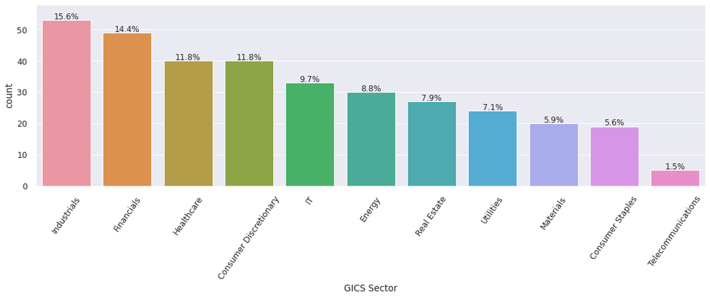

```python
# Shortening the names of certain sectors
df['GICS Sector'].replace(['Health Care', 'Information Technology', 'Telecommunications Services'],
                          ['Healthcare', 'IT', 'Telecommunications'], inplace = True)

# Plotting the frequency distribution of economic sectors
plt.figure(figsize = (18, 5));
cntplt = sns.countplot(data = df, x = 'GICS Sector', order = df['GICS Sector'].value_counts().index);
countplot_labeling(cntplt, df);
plt.xticks(rotation = 55);
plt.ylim(0, 58);
```

#### Observations:

*Industrials*, *Financials* and *Healthcare* are the most frequent economic sectors among the listed companies. *Telecommunications Services*, with only 1.5%, is the least popular one.

**`GICS Sub-Industry`**

```
No. of GICS sub-industries in the dataset: 104
```

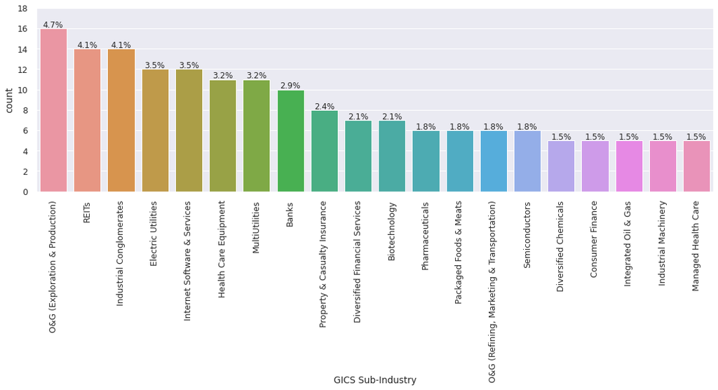

```python
# Shortening the names of certain sub-industries
df['GICS Sub-Industry'].replace(['Oil & Gas Exploration & Production', 'Oil & Gas Refining & Marketing & Transportation'],
                                ['O&G (Exploration & Production)', 'O&G (Refining, Marketing & Transportation)'],
                                inplace = True)

# No. of sub-industries in the dataset
print('No. of GICS sub-industries in the dataset:', df['GICS Sub-Industry'].nunique(), end = '\n'*2)

# Plotting the frequency distribution of sub-industries
plt.figure(figsize = (18, 5));
cntplt = sns.countplot(data = df, x = 'GICS Sub-Industry',
                       order = df['GICS Sub-Industry'].value_counts().index[0:20]);
countplot_labeling(cntplt, df);
plt.xticks(rotation = 90);
cntplt.xaxis.labelpad = -10;
plt.ylim(0, 18);
```

#### Observations:

- *Oil & Gas (Exploration and Production)*, *Real Estate Investment Trusts (REITs)* and *Industrial Conglomerates* are, respectively, the most popular sub-industries among the given companies, although the percentage of no sub-industry exceeds 4.7%.
- For the sake of better visualization, only the top 20 sub-industries (out of the total of 104) have been shown.

**`Current Price`**

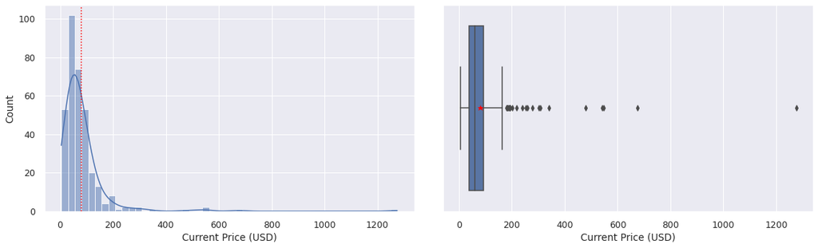

```python
plt.figure(figsize = (16, 5));
plt.subplot(121);
# Histogram
sns.histplot(data = df, x = 'Current Price', kde = True, bins = 50);
plt.axvline(df['Current Price'].mean(), color = 'red', linestyle = ':');
plt.xlabel('Current Price (USD)');
# Boxplot
plt.subplot(122);
sns.boxplot(data = df, x = 'Current Price', showmeans = True, meanprops =
            {'marker': '*', 'markerfacecolor': 'red', 'markeredgecolor': 'red', 'markersize': '9'});
plt.xlabel('Current Price (USD)');
plt.tight_layout(w_pad = 3);
```

```python
# Company with the highest stock price
df.loc[df['Current Price'] > 1200]
```

|  | Ticker Symbol | Security | GICS Sector | GICS Sub-Industry | Current Price | Price Change | Volatility | ROE | Cash Ratio | Net Cash Flow | Net Income | Earnings per Share | Outstanding Shares | P/E Ratio | P/B Ratio |
| --- | --- | --- | --- | --- | --- | --- | --- | --- | --- | --- | --- | --- | --- | --- | --- |
| 243 | PCLN | Priceline.com Inc | Consumer Discretionary | Internet & Direct Marketing Retail | 1274.950 | 3.191 | 1.268 | 29 | 184 | -1671386000 | 2551360000 | 50.090 | 50935516.070 | 25.453 | -1.052 |

#### Observations:

- The red dotted line and asterisk indicate the mean value.
- While the mean and median stock prices reside well below 100, there are several companies with outlier stock prices, making the overall distribution very right-skewed. Especially one with the stock price above 1200 USD stands out, but PCLN is known for its high stock prices, so it doesn't seem to be a mistake. For instance today's PCLN stock value is around $2000.

**`Price Change`**

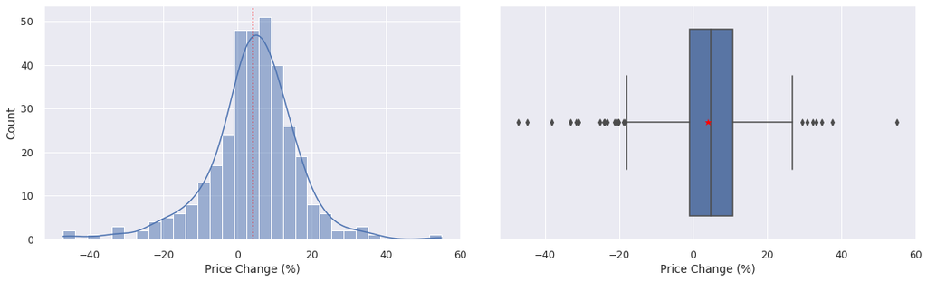

```python
plt.figure(figsize = (16, 5));
plt.subplot(121);
# Histogram
sns.histplot(data = df, x = 'Price Change', kde = True);
plt.axvline(df['Price Change'].mean(), color = 'red', linestyle = ':');
plt.xlabel('Price Change (%)');
# Boxplot
plt.subplot(122);
sns.boxplot(data = df, x = 'Price Change', showmeans = True, meanprops =
            {'marker': '*', 'markerfacecolor': 'red', 'markeredgecolor': 'red', 'markersize': '9'});
plt.xlabel('Price Change (%)');
plt.tight_layout(w_pad = 3);
```

#### Observations:

- Although not completely, but the overall distribution of price change is fairly balanced and relatively normal, with outliers appearing on both sides of the boxplot, ranging from -47 to 55.
- The mean and median of the price change are about 4.1% and 4.8%, respectively, indicating the modest growth of the market over the past quarter (13 weeks).

**`Volatility`**

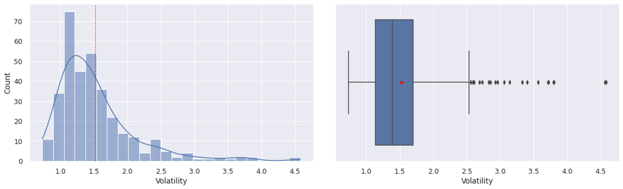

```python
plt.figure(figsize = (16, 5));
plt.subplot(121);
# Histogram
sns.histplot(data = df, x = 'Volatility', kde = True);
plt.axvline(df['Volatility'].mean(), color = 'red', linestyle = ':');
# Boxplot
plt.subplot(122);
sns.boxplot(data = df, x = 'Volatility', showmeans = True, meanprops =
            {'marker': '*', 'markerfacecolor': 'red', 'markeredgecolor': 'red', 'markersize': '9'});
plt.tight_layout(w_pad = 3);
```

#### Observations:

The average volatility index of the market in the past quarter falls around 1.53 (with a median fairly close to mean), but some outlier companies show higher levels of volatility.

**`ROE`**

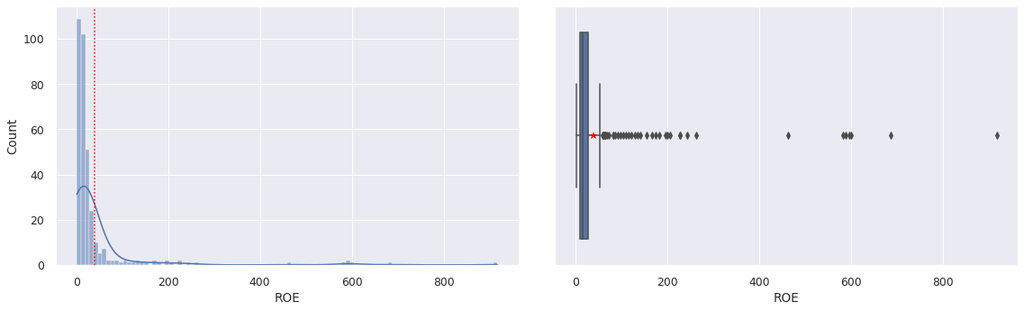

```python
plt.figure(figsize = (16, 5));
plt.subplot(121);
# Histogram
sns.histplot(data = df, x = 'ROE', kde = True, bins = 100);
plt.axvline(df['ROE'].mean(), color = 'red', linestyle = ':');
# Boxplot
plt.subplot(122);
sns.boxplot(data = df, x = 'ROE', showmeans = True, meanprops =
            {'marker': '*', 'markerfacecolor': 'red', 'markeredgecolor': 'red', 'markersize': '9'});
plt.tight_layout(w_pad = 3);
```

#### Observations:

- The mean return of equity (ROE) is around 40, i.e., on average, the companies' net income is 40 times larger than their total assets (debts subtracted).
- The ROE distribution is very right-skewed, with many outliers on the right side of the boxplot. In particular, there are several companies with ROEs above 400. This might have been caused due to the large income of these companies and/or their low assets and massive debts, making the denominator of the ROE small. Note that the difference between company's assets and debts appears in the denominator of ROE.

**`Cash Ratio`**

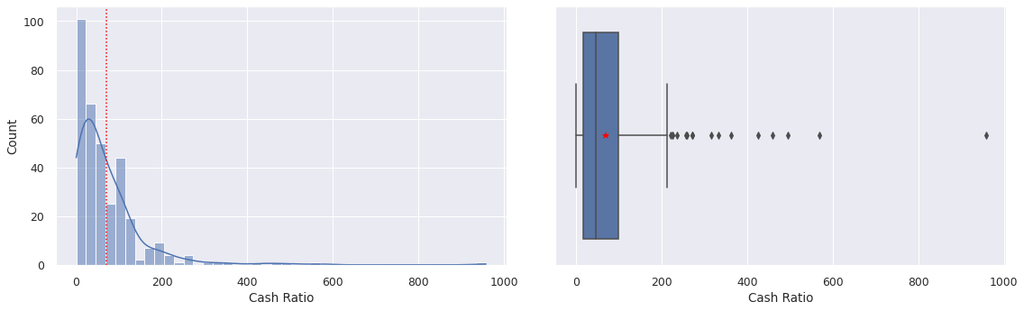

```python
plt.figure(figsize = (16, 5));
plt.subplot(121);
# Histogram
sns.histplot(data = df, x = 'Cash Ratio', kde = True);
plt.axvline(df['Cash Ratio'].mean(), color = 'red', linestyle = ':');
# Boxplot
plt.subplot(122);
sns.boxplot(data = df, x = 'Cash Ratio', showmeans = True, meanprops =
            {'marker': '*', 'markerfacecolor': 'red', 'markeredgecolor': 'red', 'markersize': '9'});
plt.tight_layout(w_pad = 3);
```

#### Observations:

- 50% of companies have a cash ratio (sum of all cash reserves and equivalents to total liabilities) of 47 or larger, while the average cash ratio is about 70.
- The cash ratio distribution is right-skewed with several outliers on the right side of the main boxplot. In particular, a few companies with a strong monetary stance have cash ratios above 400.

**`Net Cash Flow`**

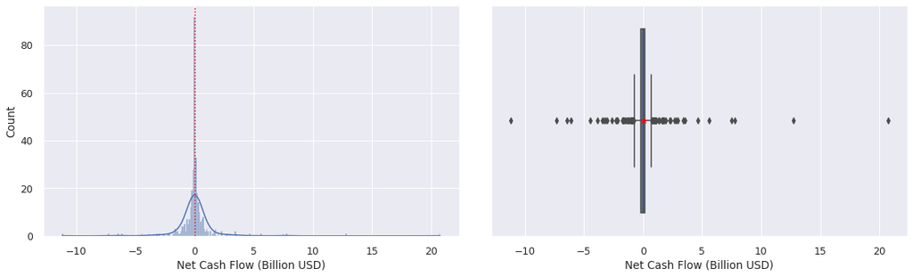

```python
plt.figure(figsize = (16, 5));
plt.subplot(121);
# Histogram
sns.histplot(x = df['Net Cash Flow']/1e9, kde = True);
plt.axvline(df['Net Cash Flow'].mean()/1e9, color = 'red', linestyle = ':');
plt.xlabel('Net Cash Flow (Billion USD)');
# Boxplot
plt.subplot(122);
sns.boxplot(x = df['Net Cash Flow']/1e9, showmeans = True, meanprops =
            {'marker': '*', 'markerfacecolor': 'red', 'markeredgecolor': 'red', 'markersize': '9'});
plt.xlabel('Net Cash Flow (Billion USD)');
plt.tight_layout(w_pad = 3);
```

#### Observations:

- The distribution of the net cash flow has dozens of outliers on both sides of the main boxplot, as there are some companies with billions of dollars in net cash outflow (extremely high cash burn rates) and some with billions of dollars in net cash inflow (strong fundraising and/or high profitability), evidencing the high variability of this attribute.
- Regardless of outliers, most companies have (positive or negative) cash flows much lower than the minimum or maximum values (only in the order of millions). The median and mean net cash flows are around \$2M and \$55M, respectively.

**`Net Income`**

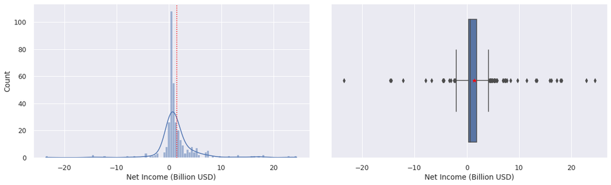

```python
plt.figure(figsize = (16, 5));
plt.subplot(121);
# Histogram
sns.histplot(x = df['Net Income']/1e9, kde = True);
plt.axvline(df['Net Income'].mean()/1e9, color = 'red', linestyle = ':');
plt.xlabel('Net Income (Billion USD)');
# Boxplot
plt.subplot(122);
sns.boxplot(x = df['Net Income']/1e9, showmeans = True, meanprops =
            {'marker': '*', 'markerfacecolor': 'red', 'markeredgecolor': 'red', 'markersize': '9'});
plt.xlabel('Net Income (Billion USD)');
plt.tight_layout(w_pad = 3);
```

#### Observations:

- Similar to net cash flow, net income also has a very high variability, with several highly thriving companies having net incomes in the order of billions, and some severely struggling companies having negative net incomes, again, in the order of billions.
- Regardless, most companies are doing moderately well, rendering the median and mean values of net income around \$0.7B and \$1.5B, respectively.

**`Earnings per Share`**

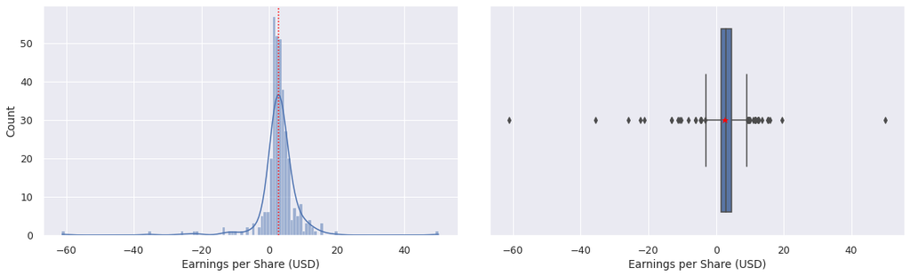

```python
plt.figure(figsize = (16, 5));
plt.subplot(121);
# Histogram
sns.histplot(data = df, x = 'Earnings per Share', kde = True);
plt.axvline(df['Earnings per Share'].mean(), color = 'red', linestyle = ':');
plt.xlabel('Earnings per Share (USD)');
# Boxplot
plt.subplot(122);
sns.boxplot(data = df, x = 'Earnings per Share', showmeans = True, meanprops =
            {'marker': '*', 'markerfacecolor': 'red', 'markeredgecolor': 'red', 'markersize': '9'});
plt.xlabel('Earnings per Share (USD)');
plt.tight_layout(w_pad = 3);
```

#### Observations:

- There are several outliers on both sides of the main boxplot, generated by struggling companies which lose money rapidly (large negative earnings per share), and highly profitable companies (large positive earnings per share).
- Nonetheless, most companies do somewhere in the middle, and, as a consequence, the mean and median of earnings per share find modest values around \$2.8 and \$2.9, respectively.

**`Estimated Shares Outstanding`**

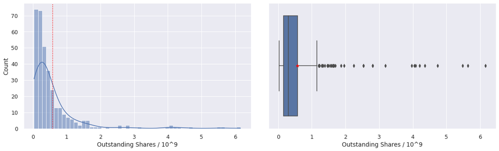

```python
plt.figure(figsize = (16, 5));
plt.subplot(121);
# Histogram
sns.histplot(x = df['Outstanding Shares']/1e9, kde = True);
plt.axvline(df['Outstanding Shares'].mean()/1e9, color = 'red', linestyle = ':');
plt.xlabel('Outstanding Shares / 10^9');
# Boxplot
plt.subplot(122);
sns.boxplot(x = df['Outstanding Shares']/1e9, showmeans = True, meanprops =
            {'marker': '*', 'markerfacecolor': 'red', 'markeredgecolor': 'red', 'markersize': '9'});
plt.xlabel('Outstanding Shares / 10^9');
plt.tight_layout(w_pad = 3);
```

#### Observations:

- The estimated shares outstanding has a very right-skewed distribution, with several outliers on the right side of the boxplot. It also has a very large variation, with its minimum and maximum falling around 28 million and 6.2 billion.
- As a result of right-skewedness, there is a massive gap between the measures of central tendencies and the maximum. So, unsurprisingly, the median and mean of outstanding shares reside around 310 million and 577 million, respectively.

**`P/E Ratio`**

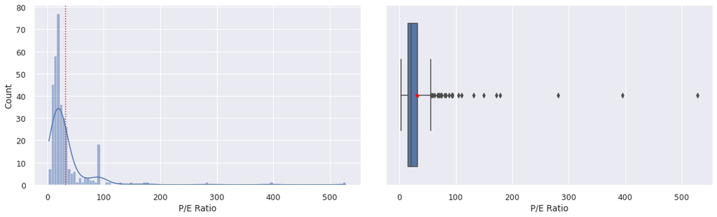

```python
plt.figure(figsize = (16, 5));
plt.subplot(121);
# Histogram
sns.histplot(data = df, x = 'P/E Ratio', kde = True);
plt.axvline(df['P/E Ratio'].mean(), color = 'red', linestyle = ':');
# Boxplot
plt.subplot(122);
sns.boxplot(data = df, x = 'P/E Ratio', showmeans = True, meanprops =
            {'marker': '*', 'markerfacecolor': 'red', 'markeredgecolor': 'red', 'markersize': '9'});
plt.tight_layout(w_pad = 3);
```

#### Observations:

The P/E ratio has a very right-skewed distribution. While the P/E ratio for some overvalued or expectedly fast-growing companies is in the order of hundreds, most companies have modest P/E ratios, rendering the median and mean values of this parameter around 21 and 33, respectively.

**`P/B Ratio`**

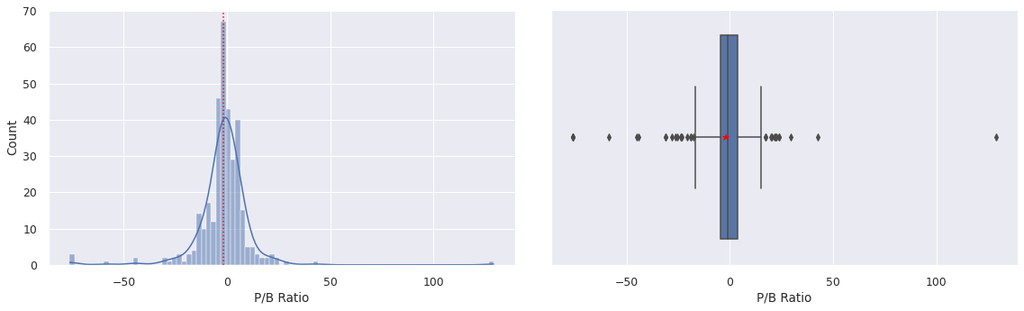

```python
plt.figure(figsize = (16, 5));
plt.subplot(121);
# Histogram
sns.histplot(data = df, x = 'P/B Ratio', kde = True);
plt.axvline(df['P/B Ratio'].mean(), color = 'red', linestyle = ':');
# Boxplot
plt.subplot(122);
sns.boxplot(data = df, x = 'P/B Ratio', showmeans = True, meanprops =
            {'marker': '*', 'markerfacecolor': 'red', 'markeredgecolor': 'red', 'markersize': '9'});
plt.tight_layout(w_pad = 3);
```

#### Observations:

- The median of the P/B ratio is negative (-1.07), indicating that, for majority of companies, the BVPS is less than zero, or, alternatively, the total liabilities overwhelm the total assets. The mean P/B ratio is also negative (-1.72).
- The P/B ratio has a very high variability, ranging from ~ -76 to ~ 129. Large values of the P/B ratio correspond to companies that have already done their growth, and their stock prices might be overvalued.

### Bivariate Analysis

The given dataset consists of several columns, making the number of possible bivariate analyses quite large. Therefore, we limit our bivariate analysis to the understanding of the relationships between some of the most important variables, while being guided by the leading questions.

**`Heatmap of Correlation Coefficients`**

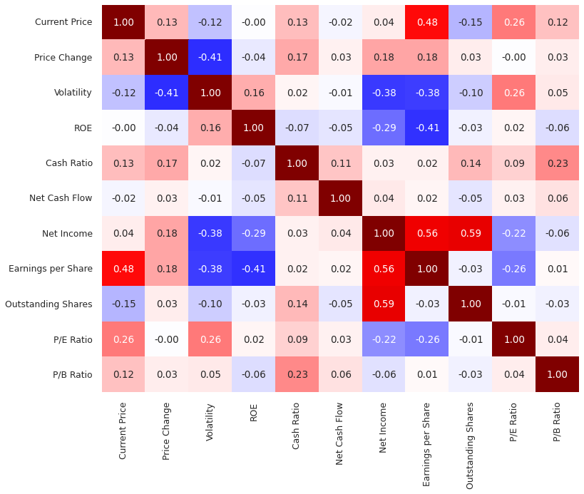

```python
plt.figure(figsize = (12, 10));
sns.heatmap(data = df.corr(), fmt = '.2f', annot = True, cmap = 'seismic', cbar = False,
            vmin = -1, vmax = 1);
```

#### Observations:

- More than any other factor, the stock price of a company is correlated with its earnings per share, that is the profit the company makes (per share).
- Volatility index and the percentage of price change have a sizeable negative correlation, i.e., companies with declining stock prices have higher volatility.
- Volaitility is also negatively correlated with net income and earnings per share, i.e., companies with a better monetary stance (higher incomes and profits) have a steadier stock price.
- Oddly, the correlation table shows that companies with higher ROEs have lower net incomes and earnings per share. This might have been caused by outliers, or companies with small assets and large debts, for which the denominator of the ROE becomes small.
- Companies with higher ratios of cash reserves to liabilities tend to have higher P/B ratios. Note that lower liabilities mean than the book value per share which appears in the denominator of the P/B ratio can remain above zero, yielding a positive value for the P/B ratio.
- Net cash flow and cash ratio appear to have a small positive correlation. Naturally, companies with a positive flow of cash are also expected to have larger cash reserves, and thus larger cash ratios.
- Companies with large profits are also expected to have higher incomes, explaining the large positive correlation between earnings per share and net income.
- Companies with higher net incomes tend to have higher outstanding shares. This makes sense as a major source of revenue (income) for a company is public sale of its stocks, therefore increasing the number of shares outstanding.

**`Price Change vs. Sector`**

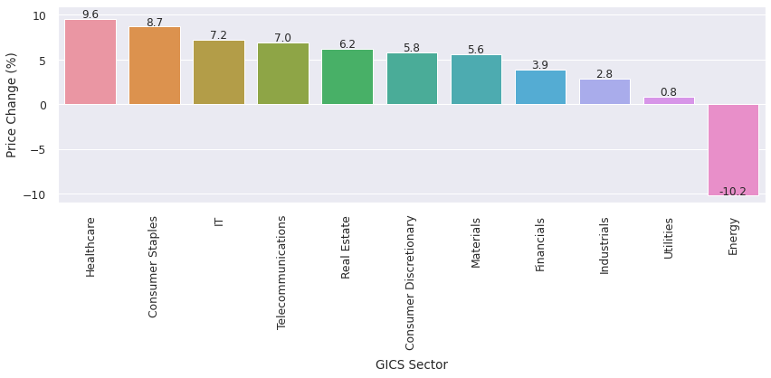

```python
# Barplot of price changes w.r.t. economic sectors
plt.figure(figsize = (14, 4));
barplt = sns.barplot(data = df, x = 'GICS Sector', y = 'Price Change', ci = False,
                     order = df.groupby(['GICS Sector'])['Price Change'].mean().sort_values(ascending = False).index);
countplot_labeling(barplt, df, perc = False);
plt.xticks(rotation = 90);
plt.ylabel('Price Change (%)');
barplt.xaxis.labelpad = 10;
plt.ylim(-11, 11);
```

#### Observations:

- In the past quarter, the *Healthcare*, *Consumer Staples* and *IT* sectors have respectively shown the largest growth, while the *Energy* sector has been the only economic sector with negative price change.
- Note that these numbers are approximations and come with their own regions of uncertainty, which we have turned off by setting ci = False. In some cases, approximations might be coarser, as only a few companies appear in certain sectors.

**`Cash Ratio vs. Sector`**

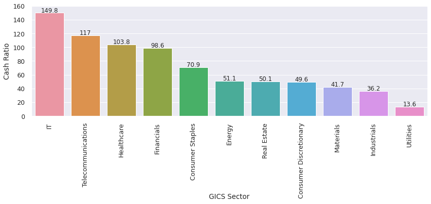

```python
# Barplot of cash ratio w.r.t. economic sectors
plt.figure(figsize = (14, 4));
barplt = sns.barplot(data = df, x = 'GICS Sector', y = 'Cash Ratio', ci = False,
                     order = df.groupby(['GICS Sector'])['Cash Ratio'].mean().sort_values(ascending = False).index);
countplot_labeling(barplt, df, perc = False);
plt.xticks(rotation = 90);
barplt.xaxis.labelpad = -10;
plt.ylim(0, 160);
```

#### Observations:

- The *IT*, *Telecommunications* and *Healthcare* sectors have the highest cash ratios, respectively. This is anticipated, as these sectors (especially IT) are known for their recent rapid growths, and will take on many obligations, requiring them to have lots of cash in hand.
- The *Utilities* sector has the lowest cash ratio on average.

**`P/E Ratio vs. Sector`**

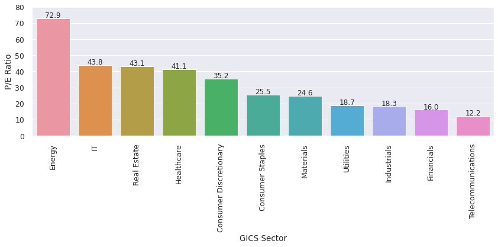

```python
# Barplot of P/E ratio changes w.r.t. economic sectors
plt.figure(figsize = (14, 4));
barplt = sns.barplot(data = df, x = 'GICS Sector', y = 'P/E Ratio', ci = False,
                     order = df.groupby(['GICS Sector'])['P/E Ratio'].mean().sort_values(ascending = False).index);
countplot_labeling(barplt, df, perc = False);
plt.xticks(rotation = 90);
plt.ylim(0, 80);
```

#### Observations:

- The P/E ratio of the *Energy* sector is visibly higher than the other economic sectors. This is compatible with the price drop of this sector, as a high P/E ratio indicates that a certain stock is overvalued, and its price will most likely declines until it adjusts to the market expectations.
- After the Energy sector, the IT, Real Estate and Healtchcare sectors rank as the economic sectors with the highest P/E ratios, in the exact same order, and with their P/E ratios standing slightly above 40.
- The *Telecommunications* sector has the lowest P/E ratio, which may imply the stock prices of this sector are, on average, undervalued, signaling their growth in the upcoming quarters.

**`Volatility vs. Sector`**

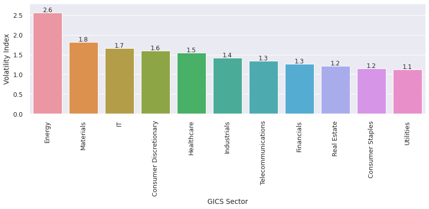

```python
# Barplot of volatility index w.r.t. economic sectors
plt.figure(figsize = (14, 4));
barplt = sns.barplot(data = df, x = 'GICS Sector', y = 'Volatility', ci = False,
                     order = df.groupby(['GICS Sector'])['Volatility'].mean().sort_values(ascending = False).index);
countplot_labeling(barplt, df, perc = False);
plt.xticks(rotation = 90);
plt.ylabel('Volatility Index');
plt.ylim(0, 2.8);
```

#### Observations:

- Consistent with its substantial price drop in the last quarter, the *Energy* sector shows highest volatility.
- After the Energy sector, *Materials* and *IT* have undergone the highest fluctuations in their stock prices, but for both sectors, all the fluctations have resulted in an average price increase.
- The *Utilities* sector has had the lowest volatility, which, considering the very slim rise in its stock prices, isn't surprising.

## Data Preprocessing

- *Missing value treatment*: No missing values were detected in the EDA section, so this step won't be necessary.
- *Outlier check*: We take a closer look at the distributions of numerical variables to determine whether the treatment of outliers will be crucial before clustering or whether any of outliers are irregular and odd.
- *Scaling*: Since the units and ranges of variables are significantly different from one another, transforming them so that they all fall within the same range and order of magnitude is vital prior to any distance-based clustering. We will use standard scaling (removing the mean of all numerical attributes and dividing the result by their corresponding standard deviations) to achieve this goal.

### Outlier Check

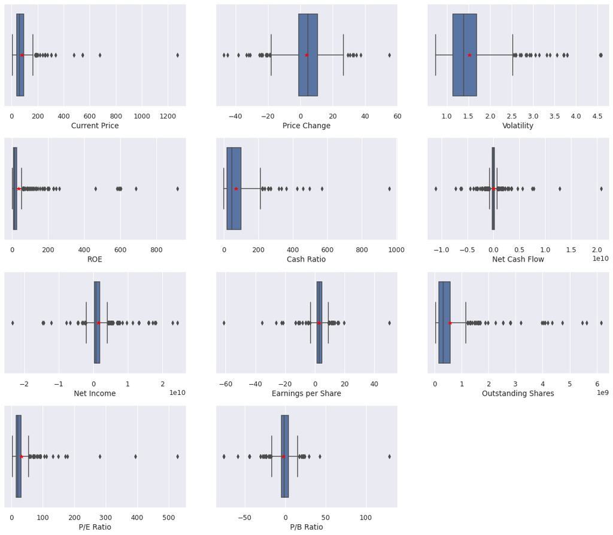

```python
plt.figure(figsize = (16, 14));
# Looping over all numerical variables
for i, col in enumerate(df.select_dtypes(include = np.number).columns.tolist()):
    plt.subplot(4, 3, i+1);
    # Boxplot distribution of a certain numerical variable
    sns.boxplot(data = df, x = col, showmeans = True, meanprops =
                {'marker': '*', 'markerfacecolor': 'red', 'markeredgecolor': 'red', 'markersize': '9'});
plt.tight_layout(w_pad = 3);
```

#### Observations:

- However all numerical variables reveal several outliers, some on both sides of the main boxplot, but since they all seem to be part of the actual data, pertaining to highly successful or struggling companies, and their presence may actually corresponds to a separate and informative cluster of data, we choose not to alter outliers in any forms.

### Scaling

```python
# Listing all numerical columns
num_cols = df.select_dtypes(include = np.number).columns.tolist()
# Separating all numerical columns, since only those will be necessary for cluster-based modeling
df_model = df[num_cols]
# Scaling the dataframe oused for clustering
df_model_scaled = pd.DataFrame(StandardScaler().fit_transform(df_model),
                               columns = df_model.columns.tolist())
df_model_scaled.head()
```

|  | Current Price | Price Change | Volatility | ROE | Cash Ratio | Net Cash Flow | Net Income | Earnings per Share | Outstanding Shares | P/E Ratio | P/B Ratio |
| --- | --- | --- | --- | --- | --- | --- | --- | --- | --- | --- | --- |
| 0 | -0.393 | 0.494 | 0.273 | 0.990 | -0.211 | -0.339 | 1.554 | 1.309 | 0.108 | -0.652 | -0.507 |
| 1 | -0.221 | 0.355 | 1.137 | 0.938 | 0.077 | -0.002 | 0.928 | 0.057 | 1.250 | -0.312 | -0.504 |
| 2 | -0.367 | 0.602 | -0.427 | -0.193 | -0.033 | 0.454 | 0.744 | 0.025 | 1.098 | -0.392 | 0.095 |
| 3 | 0.134 | 0.826 | -0.285 | -0.317 | 1.218 | -0.152 | -0.220 | -0.231 | -0.092 | 0.947 | 0.424 |
| 4 | -0.261 | -0.493 | 0.296 | -0.266 | 2.237 | 0.134 | -0.203 | -0.375 | 1.978 | 3.293 | 0.199 |

```python
print('Mean of numerical columns after scaling:\n', df_model_scaled.mean(), sep = '', end = '\n'*2)
print('Standard deviation of numerical columns after scaling:\n', df_model_scaled.std(ddof = 0), sep = '')
```

```
Mean of numerical columns after scaling:
Current Price         0.000
Price Change         -0.000
Volatility           -0.000
ROE                   0.000
Cash Ratio           -0.000
Net Cash Flow         0.000
Net Income            0.000
Earnings per Share    0.000
Outstanding Shares   -0.000
P/E Ratio             0.000
P/B Ratio             0.000
dtype: float64

Standard deviation of numerical columns after scaling:
Current Price        1.000
Price Change         1.000
Volatility           1.000
ROE                  1.000
Cash Ratio           1.000
Net Cash Flow        1.000
Net Income           1.000
Earnings per Share   1.000
Outstanding Shares   1.000
P/E Ratio            1.000
P/B Ratio            1.000
dtype: float64
```

- We have successfully created a scaled dataframe of numerical variables.
- Since we chose not to apply any outlier treatment to the data, and scaling doesn't change the overall distribution of any features (only their ranges), EDA after data manipulation (preprocessing) isn't required.

## K-Means Clustering

### Elbow Plot

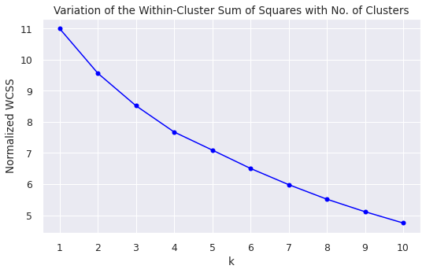

```python
# Setting the range of no. of clusters
no_clusters = np.arange(1, 11)
# Defining within-cluster summ of squares array
WCSS = np.zeros(len(no_clusters))

# Looping over no. of clusters to calculate the WCSS for each
for k in no_clusters:
    clust_model = KMeans(n_clusters = k, random_state = 1)
    segments = clust_model.fit_predict(df_model_scaled)
    WCSS[k-1] = np.sum(np.min(np.square(cdist(df_model_scaled, clust_model.cluster_centers_)), axis = 1))/df.shape[0]

# Plotting WCSS vs. k
plt.figure(figsize = (8.6, 5));
plt.plot(no_clusters, WCSS, color = 'blue', marker = 'o');
plt.xlabel('k');
plt.ylabel('Normalized WCSS');
plt.xticks(ticks = no_clusters);
plt.title('Variation of the Within-Cluster Sum of Squares with No. of Clusters');
```

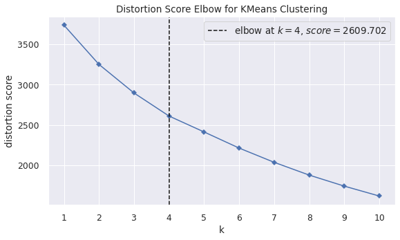

```python
# Using yellowbrick's methods to generate the k-elbow plot
plt.figure(figsize = (9, 5));
plt.xticks(ticks = no_clusters);
visualizer = KElbowVisualizer(estimator = KMeans(random_state = 1), k = no_clusters,
                              timings = False);
visualizer.fit(df_model_scaled);
visualizer.show();
```

### Silhouette Scores

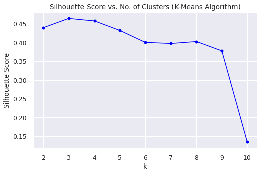

```python
# Defining the silhouette scores array
sil_scores = np.zeros(len(no_clusters)-1)

# Looping over no. of clusters to calculate the average silhouette score of each
for k in no_clusters[1:]:
    clust_model = KMeans(n_clusters = k, random_state = 1)
    segments = clust_model.fit_predict(df_model_scaled)
    sil_scores[k-2] = silhouette_score(df_model_scaled, clust_model.labels_)

# Plotting silhouette scores vs. k
plt.figure(figsize = (8, 5));
plt.plot(no_clusters[1:], sil_scores, color = 'blue', marker = 'o');
plt.xlabel('k');
plt.ylabel('Silhouette Score');
plt.title('Silhouette Score vs. No. of Clusters (K-Means Algorithm)');
```

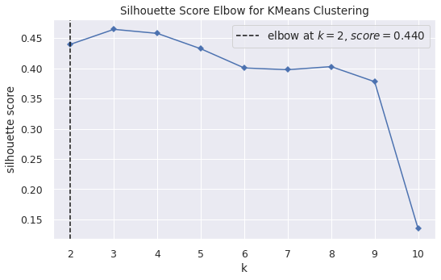

```python
# Generating silhouette score plot using yellowbrick's method
plt.figure(figsize = (8.5, 5));
visualizer = KElbowVisualizer(estimator = KMeans(random_state = 1), k = no_clusters[1:],
                              metric = 'silhouette', timings = False);
visualizer.fit(df_model_scaled);
visualizer.show();
```

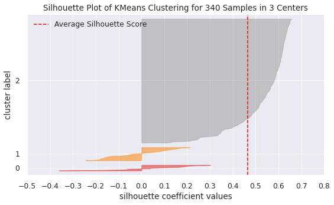

```python
# Distribution of silhouette score for different clusters when k = 3
plt.figure(figsize = (9, 5));
visualizer = SilhouetteVisualizer(estimator = KMeans(random_state = 1, n_clusters = 3));
visualizer.fit(df_model_scaled);
visualizer.show();
```

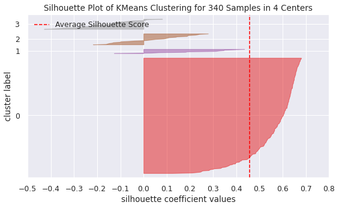

```python
# Distribution of silhouette score for different clusters when k = 4
plt.figure(figsize = (9, 5));
visualizer = SilhouetteVisualizer(estimator = KMeans(random_state = 1, n_clusters = 4));
visualizer.fit(df_model_scaled);
visualizer.show();
```

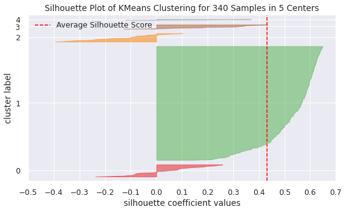

```python
# Distribution of silhouette score for different clusters when k = 5
plt.figure(figsize = (9, 5));
visualizer = SilhouetteVisualizer(estimator = KMeans(random_state = 1, n_clusters = 5));
visualizer.fit(df_model_scaled);
visualizer.show();
```

### Final Model

```python
# Copying the scaled data into a new dataframe to ensure it remains untouched for the rest of calculations
df_kmeans_scaled = df_model_scaled.copy()
# Implementing the final k-means clustering using the optimal value of k
t_i = time()
kmeans_final_model = KMeans(n_clusters = 3, random_state = 1)
kmeans_segments = kmeans_final_model.fit_predict(df_model_scaled)
t_e = time()
print('The execution of k-means algorithm takes {} seconds.'.format(round(t_e - t_i, 4)))
# Adding the clusters introduced by k-means model to the dataframes
df_kmeans_scaled['Segment'] = kmeans_segments
df_model['K-Means Segment'] = kmeans_segments
```

```
The execution of k-means algorithm takes 0.0482 seconds.
```

```python
# Let's add the sectors and sub-industries back to the df_model (unscaled modeling dataframe)
df_model['GICS Sector'] = df['GICS Sector']
df_model['GICS Sub-Industry'] = df['GICS Sub-Industry']
# Ensuring that clusters have been added to the dataframes (original)
df_model.sample(7, random_state = 1)
```

|  | Current Price | Price Change | Volatility | ROE | Cash Ratio | Net Cash Flow | Net Income | Earnings per Share | Outstanding Shares | P/E Ratio | P/B Ratio | K-Means Segment | GICS Sector | GICS Sub-Industry |
| --- | --- | --- | --- | --- | --- | --- | --- | --- | --- | --- | --- | --- | --- | --- |
| 102 | 32.000 | -15.478 | 2.924 | 205 | 70 | 830000000 | -14454000000 | -35.550 | 406582278.500 | 93.089 | 1.786 | 1 | Energy | O&G (Exploration & Production) |
| 125 | 104.660 | 16.224 | 1.321 | 8 | 958 | 592000000 | 3669000000 | 1.310 | 2800763359.000 | 79.893 | 5.884 | 0 | IT | Internet Software & Services |
| 11 | 40.030 | 7.579 | 1.163 | 15 | 47 | 21818000 | 248710000 | 1.520 | 163625000.000 | 26.336 | -1.269 | 2 | Real Estate | REITs |
| 248 | 79.410 | 10.661 | 0.806 | 17 | 129 | 160383000 | 636056000 | 3.280 | 491391569.000 | 24.070 | -2.257 | 2 | Consumer Staples | Personal Products |
| 238 | 67.610 | 0.865 | 1.590 | 32 | 64 | -588000000 | -7829000000 | -10.230 | 765298142.700 | 93.089 | 3.345 | 1 | Energy | O&G (Exploration & Production) |
| 336 | 52.516 | -8.699 | 1.479 | 142 | 27 | 159000000 | 1293000000 | 2.970 | 435353535.400 | 17.682 | -3.838 | 2 | Consumer Discretionary | Restaurants |
| 112 | 52.130 | -21.254 | 2.365 | 2 | 201 | 523803000 | 85171000 | 0.560 | 152091071.400 | 93.089 | 9.568 | 1 | Energy | O&G (Exploration & Production) |

### Cluster Profiling

```python
# Separating the data points of each cluster and indicating each cluster by its centroid
km_clust_profile = df_model.groupby('K-Means Segment').mean()
# Adding the number of data points in each cluster to the cluster profiling
km_clust_profile['Count'] = df_model['K-Means Segment'].value_counts()[np.sort(df_model
                                                                               ['K-Means Segment'].value_counts().index)]
km_clust_profile.style.highlight_max(color = 'lightgreen', axis = 0)
```

| K-Means Segment | Current Price | Price Change | Volatility | ROE | Cash Ratio | Net Cash Flow | Net Income | Earnings per Share | Outstanding Shares | P/E Ratio | P/B Ratio | Count |
| --- | --- | --- | --- | --- | --- | --- | --- | --- | --- | --- | --- | --- |
| 0 | 52.142857 | 6.779993 | 1.175153 | 26.142857 | 140.142857 | 760285714.285714 | 13368785714.285715 | 3.769286 | 3838879870.871428 | 20.654832 | -3.529270 | 14 |
| 1 | 64.183438 | -10.557046 | 2.797776 | 96.531250 | 70.718750 | 159171125.000000 | -3250005968.750000 | -7.886875 | 526459323.057500 | 111.333230 | 1.783445 | 32 |
| 2 | 84.045331 | 5.542488 | 1.404255 | 34.040816 | 66.608844 | 10698350.340136 | 1445333183.673469 | 3.890051 | 427206184.715408 | 24.613743 | -2.013147 | 294 |

#### Observations:

- Cluster 0 consists of large and successful corporations with high net incomes, cash flows and large sums of cash reserves and cash equivalents with steady stock prices (low volatility). Since the sizes of these companies are quite large and the numbers of their investors are also quite high , they have the highest average value for estimated shares outstanding as well.
- Cluster 1 represents struggling companies with declining and high-volatility stock prices and negative net incomes. The average P/E ratio of this cluster is really high, perhaps suggesting that the stocks of most companies in this cluster are overvalued.
- The vast majority of companies (86.5%) lie in cluster 2. The average stock price of this cluster is higher than the other two, and it also has the highest earnings per share. However the net income of companies inside this cluster is smaller than that of companies in cluster 0, but since they have fewer shares outstanding (and fewer shares) the profit dividend they pay their investors for each share is higher (but still close to that of cluster 0).

```python
# Printing the name of companies in each cluster
for k in range(3):
    print('All companies in cluster ', k, ':\n',
          np.array(df.loc[df_model['K-Means Segment'] == k]['Security'].values.tolist()), sep = '', end = '\n'*2)
```

```
All companies in cluster 0:
['Bank of America Corp' 'Citigroup Inc.' 'Ford Motor' 'Facebook'
 'Gilead Sciences' 'Intel Corp.' 'JPMorgan Chase & Co.'
 'Coca Cola Company' 'Merck & Co.' 'Pfizer Inc.' 'AT&T Inc'
 'Verizon Communications' 'Wells Fargo' 'Exxon Mobil Corp.']

All companies in cluster 1:
['Analog Devices, Inc.' 'Alexion Pharmaceuticals' 'Amazon.com Inc'
 'Apache Corporation' 'Anadarko Petroleum Corp' 'Baker Hughes Inc'
 'Chesapeake Energy' 'Cabot Oil & Gas' 'Concho Resources'
 'Devon Energy Corp.' 'EOG Resources' 'EQT Corporation'
 'Freeport-McMoran Cp & Gld' 'Halliburton Co.' 'Hess Corporation'
 'Hewlett Packard Enterprise' 'Kinder Morgan' 'Marathon Oil Corp.'
 'Murphy Oil' 'Noble Energy Inc' 'Netflix Inc.' 'Newfield Exploration Co'
 'National Oilwell Varco Inc.' 'ONEOK' 'Occidental Petroleum'
 'Quanta Services Inc.' 'Range Resources Corp.' 'Southwestern Energy'
 'Teradata Corp.' 'Williams Cos.' 'Wynn Resorts Ltd' 'Cimarex Energy']

All companies in cluster 2:
['American Airlines Group' 'AbbVie' 'Abbott Laboratories'
 'Adobe Systems Inc' 'Archer-Daniels-Midland Co' 'Alliance Data Systems'
 'Ameren Corp' 'American Electric Power' 'AFLAC Inc'
 'American International Group, Inc.' 'Apartment Investment & Mgmt'
 'Assurant Inc' 'Arthur J. Gallagher & Co.' 'Akamai Technologies Inc'
 'Albemarle Corp' 'Alaska Air Group Inc' 'Allstate Corp' 'Allegion'
 'Applied Materials Inc' 'AMETEK Inc' 'Affiliated Managers Group Inc'
 'Amgen Inc' 'Ameriprise Financial' 'American Tower Corp A'
 'AutoNation Inc' 'Anthem Inc.' 'Aon plc' 'Amphenol Corp' 'Arconic Inc'
 'Activision Blizzard' 'AvalonBay Communities, Inc.' 'Broadcom'
 'American Water Works Company Inc' 'American Express Co' 'Boeing Company'
 'Baxter International Inc.' 'BB&T Corporation' 'Bard (C.R.) Inc.'
 'BIOGEN IDEC Inc.' 'The Bank of New York Mellon Corp.' 'Ball Corp'
 'Bristol-Myers Squibb' 'Boston Scientific' 'BorgWarner'
 'Boston Properties' 'Caterpillar Inc.' 'Chubb Limited' 'CBRE Group'
 'Crown Castle International Corp.' 'Carnival Corp.' 'Celgene Corp.'
 'CF Industries Holdings Inc' 'Citizens Financial Group' 'Church & Dwight'
 'C. H. Robinson Worldwide' 'Charter Communications' 'CIGNA Corp.'
 'Cincinnati Financial' 'Colgate-Palmolive' 'Comerica Inc.'
 'CME Group Inc.' 'Chipotle Mexican Grill' 'Cummins Inc.' 'CMS Energy'
 'Centene Corporation' 'CenterPoint Energy' 'Capital One Financial'
```

[output cut: 57 more lines]

```
 'Skyworks Solutions' 'Synchrony Financial' 'Stryker Corp.'
 'Molson Coors Brewing Company' 'Tegna, Inc.' 'Torchmark Corp.'
 'Thermo Fisher Scientific' 'TripAdvisor' 'The Travelers Companies Inc.'
 'Tractor Supply Company' 'Tyson Foods' 'Tesoro Petroleum Co.'
 'Total System Services' 'Texas Instruments' 'Under Armour'
 'United Continental Holdings' 'UDR Inc' 'Universal Health Services, Inc.'
 'United Health Group Inc.' 'Unum Group' 'Union Pacific'
 'United Parcel Service' 'United Technologies' 'Varian Medical Systems'
 'Valero Energy' 'Vulcan Materials' 'Vornado Realty Trust'
 'Verisk Analytics' 'Verisign Inc.' 'Vertex Pharmaceuticals Inc'
 'Ventas Inc' 'Waters Corporation' 'Wec Energy Group Inc'
 'Whirlpool Corp.' 'Waste Management Inc.' 'Western Union Co'
 'Weyerhaeuser Corp.' 'Wyndham Worldwide' 'Xcel Energy Inc' 'XL Capital'
 'Dentsply Sirona' 'Xerox Corp.' 'Xylem Inc.' 'Yahoo Inc.'
 'Yum! Brands Inc' 'Zimmer Biomet Holdings' 'Zions Bancorp' 'Zoetis']
```

```python
# Grouping data points of each cluster based on their economic sector
pd.crosstab(df_model['K-Means Segment'], df_model['GICS Sector']).style.highlight_max(
                                                        color = 'lightgreen', axis = 1)
```

| GICS Sector K-Means Segment | Consumer Discretionary | Consumer Staples | Energy | Financials | Healthcare | IT | Industrials | Materials | Real Estate | Telecommunications | Utilities |
| --- | --- | --- | --- | --- | --- | --- | --- | --- | --- | --- | --- |
| 0 | 1 | 1 | 1 | 4 | 3 | 2 | 0 | 0 | 0 | 2 | 0 |
| 1 | 2 | 0 | 23 | 0 | 1 | 4 | 1 | 1 | 0 | 0 | 0 |
| 2 | 37 | 18 | 6 | 45 | 36 | 27 | 52 | 19 | 27 | 3 | 24 |

#### Observations:

- Cluster 0, which is characterized by the presence of giant and prominent corporations, which have high cash flows and net incomes, is unsurprisingly dominated by colossal financial institutions such as Bank of America and Wells Fargo and massive pharmaceutical companies such as Pfizer and Gilead.
- The vast majority of companies in cluster 1 are Energy companies, which, as discussed already, have high volatility and negative price change. These two properties, have consequently been carried to this cluster.
- Although the plurality of cluster 2 is made up of Industrial companies, the majority of companies from all other sectors (except Energy) also fall in this cluster, as this cluster has the highest count by far.

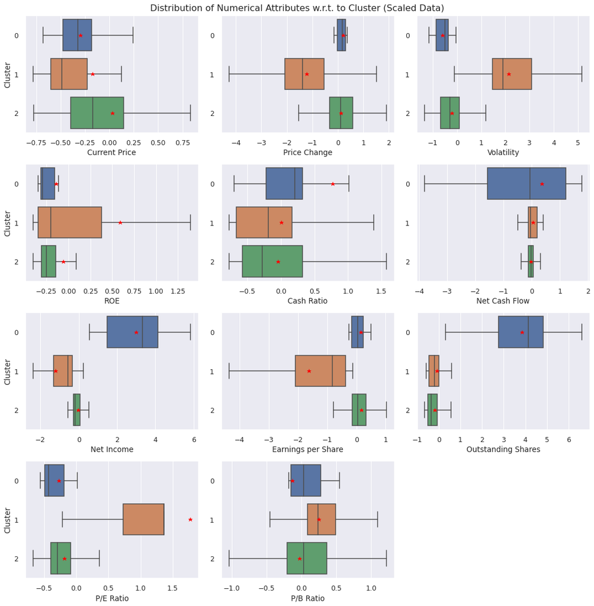

```python
# Demonstrating the boxplots of numerical variables for each cluster (scaled data)
plt.figure(figsize = (16, 16));
plt.suptitle('Distribution of Numerical Attributes w.r.t. to Cluster (Scaled Data)');
for i, col in enumerate(df_kmeans_scaled.drop(columns = 'Segment').columns.tolist()):
    plt.subplot(4, 3, i+1);
    sns.boxplot(data = df_kmeans_scaled, x = col, y = 'Segment', showmeans = True, showfliers = False, orient = 'h',
                meanprops = {'marker': '*', 'markerfacecolor': 'red', 'markeredgecolor': 'red', 'markersize': '9'});
    if(i%3 == 0):
      plt.ylabel('Cluster');
    else:
      plt.ylabel('');
plt.tight_layout(pad = 3.3, h_pad = 1, w_pad = 1.5);
```

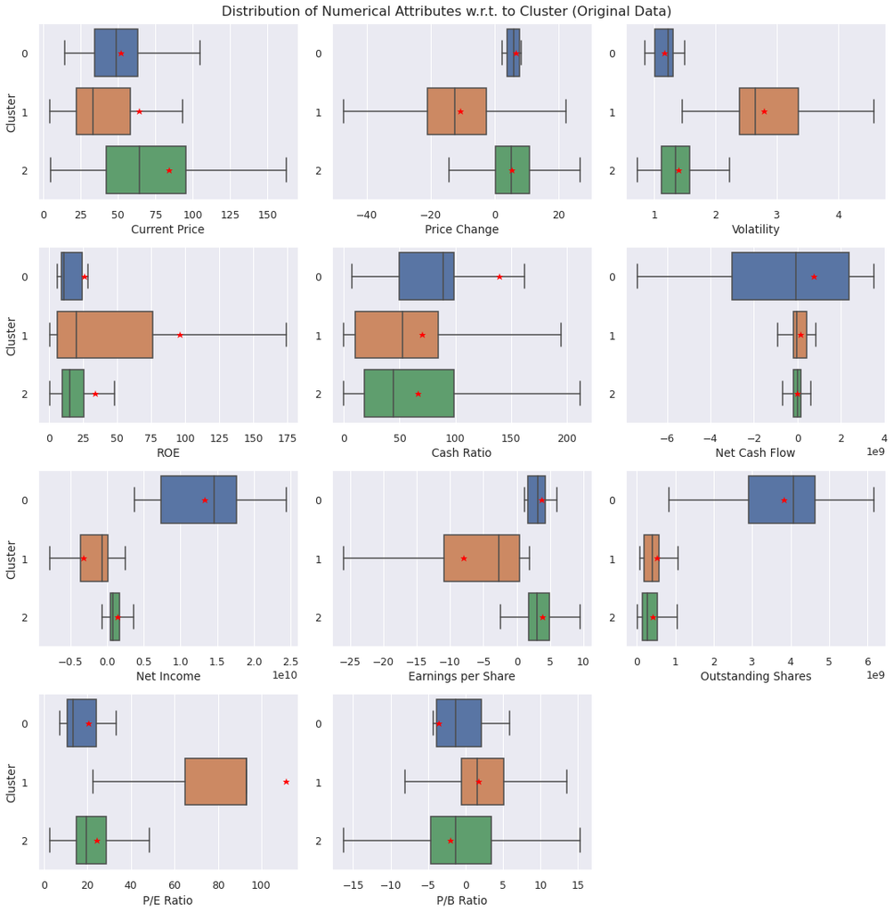

```python
# Demonstrating the boxplots of numerical variables for each cluster (original data)
plt.figure(figsize = (16, 16));
plt.suptitle('Distribution of Numerical Attributes w.r.t. to Cluster (Original Data)');
for i, col in enumerate(df_model.drop(columns = 'K-Means Segment').select_dtypes(include = np.number).columns.tolist()):
    plt.subplot(4, 3, i+1);
    sns.boxplot(data = df_model, x = col, y = 'K-Means Segment', showmeans = True, showfliers = False, orient = 'h',
                meanprops = {'marker': '*', 'markerfacecolor': 'red', 'markeredgecolor': 'red', 'markersize': '9'});
    if(i%3 == 0):
      plt.ylabel('Cluster');
    else:
      plt.ylabel('');
plt.tight_layout(pad = 3.3, h_pad = 1, w_pad = 1.5);
```

#### Notes:

The outliers haven't been shown in order to emphasize what bulk of a boxplot reveals.

#### Observations:

- **Cluster 0**:
  - Lowest average stock price, but highest percentage of price rise.
  - The volatility index is lower than the two other clusters.
  - Very high cash ratios, cash flows and net incomes.
  - The cluster mainly comprises giant corporations, explaining the very large average value of shares outstanding.
- **Cluster 1**:
  - Moderate stock prices, but as evidenced by high P/E and P/B ratios, most likely many of them are overvalued.
  - The only cluster with a positve P/B ratio, i.e., on average, the companies in this cluster have more assets than liabilities.
  - Characterized by high-volatility and declining prices.
  - Highest ROE, but negative net income and earnings per share. High ROE doesn't necessarily mean large sums of profit, as it might be cuased by low company's assets or massive debts.
  - Moderate net cash flow and cash ratio.
- **Cluster 2**:
  - Highest current stock price, with moderate volatility and fairly good price rise.
  - Lowest cash ratio and net cash flow.
  - Positive net income but much lower than the average income of cluster 0.
  - As many companies in this cluster are small or mid-sized, having the lowest shares outstanding is expected for this cluster.
  - Highest earnings per share, even slightly larger than that of cluster 0, caused by its fairly good net income and much lower shares outstanding.
  - A much larger count of companies compared to the other two clusters.

## Hierarchical Clustering

### Impact of Distance Metric and Linkage Method

**`Cophenetic Correlation`**

```python
# Linkage methods applicable with all distance metrics
common_link_methods = ['single', 'complete', 'average', 'weighted']
# Linkage and distance hyperparameters passed to linkage()
# Note that 'centroid' and 'ward' are only compatible with Euclidean distance measure
linkage_hyperparams = {'cityblock': common_link_methods, 'chebyshev': common_link_methods,
                       'Mahalanobis': common_link_methods, 'euclidean': common_link_methods + ['centroid', 'ward']}
# A dataframe of cophenetic correlations for all possible pairs of linkage methods and distance metrics
cc_df = pd.DataFrame(columns = ['Linkage Method', 'Distance Metric', 'Cophenetic Correlation'])

idx = 0 # A counter for indices of dataframe
for distance_metric in linkage_hyperparams.keys():
    for linkage_method in linkage_hyperparams[distance_metric]:
      # Implementing linkage method for a certain combination of linkage methods & distance metrics
      Z = linkage(df_model_scaled, metric = distance_metric, method = linkage_method,
                  optimal_ordering = True)
      # Calculating cophenetic correlation
      cc, coph_dists = cophenet(Z, pdist(df_model_scaled, metric = distance_metric))
      del coph_dists
      cc_df.loc[idx, :] = [linkage_method.capitalize(), distance_metric.capitalize(), cc]
      idx += 1
# Sorting the results from the highest coph. correlation to the lowest
cc_df.sort_values(by = 'Cophenetic Correlation', ascending = False)
```

|  | Linkage Method | Distance Metric | Cophenetic Correlation |
| --- | --- | --- | --- |
| 6 | Average | Chebyshev | 0.944 |
| 14 | Average | Euclidean | 0.942 |
| 10 | Average | Mahalanobis | 0.939 |
| 16 | Centroid | Euclidean | 0.931 |
| 8 | Single | Mahalanobis | 0.928 |
| 2 | Average | Cityblock | 0.926 |
| 12 | Single | Euclidean | 0.923 |
| 7 | Weighted | Chebyshev | 0.923 |
| 0 | Single | Cityblock | 0.901 |
| 4 | Single | Chebyshev | 0.894 |
| 11 | Weighted | Mahalanobis | 0.889 |
| 15 | Weighted | Euclidean | 0.869 |
| 9 | Complete | Mahalanobis | 0.824 |
| 13 | Complete | Euclidean | 0.787 |
| 3 | Weighted | Cityblock | 0.758 |
| 1 | Complete | Cityblock | 0.754 |
| 17 | Ward | Euclidean | 0.710 |
| 5 | Complete | Chebyshev | 0.612 |